# AE2

**Introduction to the project**

In this task, we will be analyzing a dataset that contains information about moderation activities on the Mastodon social platform. The data includes blocking reasons for various interactions between users, which we will use to identify and explore patterns of moderation across different instances. The primary goal is to visualize these patterns using network analysis and cosine similarity.

The dataset, stored in a CSV file, includes columns such as the source and target users involved in moderation actions, along with the associated blocking reasons (e.g., misinformation, spam, harassment). We'll filter and clean the data to focus on the most significant moderation reasons and then build a network that illustrates how these actions are connected.

**Here's a brief overview of the steps to be done in the code:**

1. **Load and Clean the Dataset**
- Load the dataset from a CSV file.
- Standardize the blocking reasons by converting them to lowercase for consistency.
- Filter out any rows with missing or empty blocking reasons.
2. **Focus on Significant Moderation Reasons**
- Define a list of significant moderation reasons such as misinformation, spam, harassment, and hate speech.
- Filter the dataset to keep only the entries that correspond to these significant moderation reasons.
3. **Create a Weighted Network Graph**
- Construct a weighted network graph where the nodes represent users, and the edges represent relationships based on similarity in moderation behavior.
- Use cosine similarity to measure the strength of these relationships.
4. **Visualize the Moderation Network**
- Visualize the moderation network using different graph layouts, like force-directed or circular, to represent the relationships clearly.
- Apply different coloring techniques to highlight the moderation activities, which can distinguish between different communities or moderation behaviors.
5. **Community Detection**
- Apply community detection algorithms, like the Louvain method, to uncover groups of users with similar moderation behaviors.
- Visualize these communities and their distribution across the network, highlighting key patterns in moderation practices.
6. **Final Visualization**
- By the end of the process, you will have an interactive and informative visualization of how moderation actions are distributed across different user interactions.
- This will help identify common and niche moderation issues and provide insights into the overall moderation behavior on the platform.

```python
# pip install pandas  # Install pandas for data manipulation and reading CSV files
# pip install scipy  # Install scipy for efficient sparse matrix operations
# pip install scikit-learn  # Install scikit-learn for calculating cosine similarity between instances
# pip install networkx  # Install the networkx package for creating and analyzing complex networks
# pip install python-louvain  # Install the python-louvain package for community detection in networks
# pip install matplotlib  # Install matplotlib for visualizing data and graphs
```

```python
import pandas as pd  # pandas for data manipulation and reading CSV files
import scipy.sparse as sp  # scipy.sparse for efficient sparse matrix operations
from sklearn.metrics.pairwise import cosine_similarity  # cosine_similarity from sklearn for calculating similarity between instances
import networkx as nx  # networkx for creating and analyzing networks/graphs
import matplotlib.pyplot as plt  # matplotlib for visualizing data and graphs
import community as community_louvain  # Louvain method for community detection
import matplotlib.cm as cm  # Importing the 'cm' module from matplotlib to access colormap functions for visualizations

class ModerationData:

    def __init__(self, file_path):
        """
        Initializes the ModerationData class with the path to the dataset.

        Args:
            file_path (str): Path to the dataset file (CSV).
        """
        self.file_path = file_path
        self.df = None  # Placeholder for the dataset

    def load_data(self):
        """Loads the dataset into a pandas DataFrame, cleans it, and displays basic information."""
        # Load the dataset
        self.df = pd.read_csv(self.file_path)

        # Convert blocking reasons to lowercase to standardize them
        if 'blocking_reason' in self.df.columns:
            self.df['blocking_reason'] = self.df['blocking_reason'].str.lower()

        # Display basic info and first 5 rows
        print("Dataset Loaded and Cleaned Successfully!")
        print(self.df.info())
        print("\nFirst 5 rows of the dataset:")
        print(self.df.head())

    def filter_empty_reasons(self):
        """Filters out rows where the 'blocking_reason' column is empty or NaN."""
        initial_count = len(self.df)
        self.df = self.df[self.df['blocking_reason'].notna() & (self.df['blocking_reason'] != '')]
        print(f"Removed {initial_count - len(self.df)} rows with empty or missing blocking reasons.")

    def filter_significant_reasons(self, significant_reasons):
        """
        Filters the dataset based on specified significant moderation reasons.

        Args:
            significant_reasons (list): List of moderation reasons to filter by.
        """
        # Ensure the reasons are in lowercase to match with the cleaned data
        significant_reasons = [reason.lower() for reason in significant_reasons]

        # Filter the dataframe based on the provided significant reasons
        initial_count = len(self.df)
        self.df = self.df[self.df['blocking_reason'].isin(significant_reasons)]

        print(f"Filtered dataset to include only the following significant reasons: {significant_reasons}")
        print(f"Rows after filtering: {len(self.df)} (Removed {initial_count - len(self.df)} rows)")

    def get_instance_moderations(self, significant_reasons):
        """
        Returns a subset of the moderation data that contains instance moderations
        for the specified significant moderation reasons.

        Args:
            significant_reasons (list): List of significant moderation reasons to filter by.

        Returns:
            pd.DataFrame: Subset of the data containing moderations for the given reasons.
        """
        # Ensure the reasons are in lowercase to match with the cleaned data
        significant_reasons = [reason.lower() for reason in significant_reasons]

        # Filter the dataframe based on the specified reasons
        instance_moderations = self.df[self.df['blocking_reason'].isin(significant_reasons)]

        print(f"Subset of the data for the following reasons: {significant_reasons}")
        print(f"Subset Rows: {len(instance_moderations)}")
        return instance_moderations

    def get_relevant_moderation_data(self, significant_reasons):
        """
        Returns a new dataset containing only the relevant entries (source, target, weight)
        for the specified moderation reasons, with the weight representing the number of
        times moderation occurred between these instances.

        Args:
            significant_reasons (list): List of significant moderation reasons to filter by.

        Returns:
            pd.DataFrame: New dataset with columns (source, target, weight) for the given reasons.
        """
        # Ensure the reasons are in lowercase to match with the cleaned data
        significant_reasons = [reason.lower() for reason in significant_reasons]

        # Filter the dataframe based on the specified reasons
        relevant_data = self.df[self.df['blocking_reason'].isin(significant_reasons)]

        # Group by source and target, and count the number of occurrences (weight)
        relevant_data_grouped = relevant_data.groupby(['source', 'target']).size().reset_index(name='weight')

        print(f"Relevant Moderation Data (with weights):")
        print(relevant_data_grouped.head())

        return relevant_data_grouped

    def create_sparse_matrix(self, relevant_moderation_data):
        """
        Creates a sparse matrix where columns represent the source instances,
        rows represent the target instances, and each cell represents the weight (number of times
        the source instance moderated the target instance).

        Args:
            relevant_moderation_data (pd.DataFrame): DataFrame containing the relevant moderation data
                                                      with columns (source, target, weight).

        Returns:
            scipy.sparse.csr_matrix: A sparse matrix representing the interactions.
        """
        # Pivot the relevant data to create a matrix with source as columns, target as rows
        pivot_df = relevant_moderation_data.pivot_table(index="target", columns="source", values="weight", fill_value=0)

        # Convert the DataFrame to a sparse matrix format (CSR format)
        sparse_matrix = sp.csr_matrix(pivot_df.values)

        print(f"Sparse Matrix Created! Shape: {sparse_matrix.shape}")
        return sparse_matrix

    def compute_cosine_similarity(self, sparse_matrix):
        """
        Calculates the cosine similarity for each pair of source instances (columns) based on the sparse matrix.
```

```python
        Args:
            sparse_matrix (scipy.sparse.csr_matrix): The sparse matrix representing interactions.

        Returns:
            pd.DataFrame: A DataFrame with cosine similarity values between source instances (columns).
        """
        # Calculate cosine similarity for each pair of columns (source instances)
        similarity_matrix = cosine_similarity(sparse_matrix.T)  # Transpose to calculate similarity for columns

        # Get the source instances (column names)
        source_instances = self.df["source"].unique()

        # Create a DataFrame with the cosine similarity values
        similarity_df = pd.DataFrame(similarity_matrix, index=source_instances, columns=source_instances)

        print("Cosine Similarity Matrix:")
        print(similarity_df.head(10))  # Displaying first 10 rows for brevity

        return similarity_df

    def create_graph_from_similarity(self, similarity_df):
        """
        Creates an undirected weighted graph from the cosine similarity matrix and plots it using
        the Fruchterman-Reingold (FR) layout.

        Args:
            similarity_df (DataFrame): Cosine similarity matrix for the source instances.
        """
        G = nx.Graph()

        # Add nodes to the graph (each source instance is a node)
        for source in similarity_df.columns:
            G.add_node(source)

        # Add edges to the graph based on similarity values
        for source in similarity_df.columns:
            for target in similarity_df.columns:
                # Only add edges with a similarity score above a certain threshold (e.g., 0.2)
                if source != target and similarity_df.loc[source, target] > 0.2:
                    G.add_edge(source, target, weight=similarity_df.loc[source, target])

        # Plot the graph using the Fruchterman-Reingold layout
        plt.figure(figsize=(8, 6))
        pos = nx.spring_layout(G, k=0.15, iterations=20)  # FR layout
        edges = G.edges(data=True)
        weights = [edge[2]['weight'] for edge in edges]

        # Draw the graph
        nx.draw(G, pos, with_labels=True, node_color='orange', edge_color=weights, edge_cmap=plt.cm.Blues, width=2)
        plt.title("Moderator Similarity Network (Fruchterman-Reingold Layout)")
        plt.show()

    def create_colored_graph(self, significant_reasons, instance_moderations_subset):
        """
        Creates an undirected weighted graph from the moderation data, colors the nodes based on moderation activities,
        and sets edge thickness proportional to the weight (frequency of moderation activity).

        Args:
            significant_reasons (list): List of significant moderation reasons (e.g., misinformation, spam).
            instance_moderations_subset (pd.DataFrame): Subset of data containing moderations for the significant reasons.
        """
        # Create the graph
        G = nx.Graph()

        # Add nodes
        for source in instance_moderations_subset['source'].unique():
            G.add_node(source)

        # Add edges with weights
        for _, row in instance_moderations_subset.iterrows():
            source = row['source']
            target = row['target']
            reason = row['blocking_reason']
            weight = row['weight']  # Assuming 'weight' represents frequency of moderation or similarity
            G.add_edge(source, target, reason=reason, weight=weight)

        # Define color mapping for reasons
        reason_colors = {
            'misinformation': 'blue',
            'spam': 'red',
            'harassment': 'green',
            'hate-speech': 'purple'
        }

        # Color nodes based on their moderation reason
        node_colors = []
        for node in G.nodes:
            node_reasons = instance_moderations_subset[instance_moderations_subset['source'] == node]['blocking_reason'].unique()
            if node_reasons.size > 0:
                reason_color = reason_colors.get(node_reasons[0], 'gray')
            else:
                reason_color = 'gray'  # Default if no reason is found
            node_colors.append(reason_color)

        # Edge widths proportional to the weight
        edge_widths = [G[u][v]['weight'] * 2 for u, v in G.edges]  # Scale the width for better visualization

        # Plotting the graph
        plt.figure(figsize=(8, 6))
        pos = nx.spring_layout(G, k=0.15, iterations=20)  # Using the spring layout for node positioning

        # Draw the graph
        nx.draw(G, pos, with_labels=False, node_color=node_colors, edge_color='gray', node_size=500, font_size=10,
                width=edge_widths)

        # Set background color to white
        plt.gca().set_facecolor('white')

        # Title for the plot
        plt.title("Moderation Activity Network")

        # Add legend for moderation reasons
        handles = []
        for reason, color in reason_colors.items():
            handles.append(plt.Line2D([0], [0], marker='o', color='w', markerfacecolor=color, markersize=10, label=reason))

        plt.legend(handles=handles, title="Moderation Activity", loc='upper right')

        # Show the plot
        plt.show()

    def detect_communities(self, similarity_df):
        """
        Detects communities in the moderation network using the Louvain method.

        Args:
            similarity_df (pd.DataFrame): Cosine similarity matrix for the source instances.

        Returns:
            dict: A dictionary mapping each node to its assigned community.
        """
        # Create a graph from the similarity matrix
        G = nx.Graph()

        # Add nodes to the graph
        for source in similarity_df.columns:
            G.add_node(source)

        # Add edges with weights (cosine similarity values)
        for source in similarity_df.columns:
            for target in similarity_df.columns:
                if source != target and similarity_df.loc[source, target] > 0.2:  # Threshold for similarity
                    G.add_edge(source, target, weight=similarity_df.loc[source, target])
```

```python
        # Apply Louvain method to detect communities
        partition = community_louvain.best_partition(G)

        return partition

    def visualize_communities(self, partition):
        """
        Visualizes the detected communities by coloring nodes based on their community.

        Args:
            partition (dict): Dictionary with nodes as keys and community labels as values.
        """
        # Create a graph from the partition
        G = nx.Graph()

        # Add nodes and edges
        for node in partition.keys():
            G.add_node(node)
        for node1 in partition.keys():
            for node2 in partition.keys():
                if node1 != node2:
                    G.add_edge(node1, node2)

        # Create a color map based on the community
        communities = list(set(partition.values()))
        community_colors = {community: plt.get_cmap('tab10')(i / len(communities)) for i, community in enumerate(communities)}

        # Assign colors to nodes based on their community
        node_colors = [community_colors[partition[node]] for node in G.nodes]

        # Plot the graph with community colors
        plt.figure(figsize=(10, 8))
        pos = nx.spring_layout(G)  # Layout for node positioning
        nx.draw(G, pos, with_labels=True, node_color=node_colors, node_size=500, font_size=10, edge_color='gray')

        # Title and display
        plt.title("Community Detection in Moderation Network")
        plt.show()

    def summarize_communities(self, similarity_df):
        """
        Summarizes community information by calculating the number of instances in each detected community,
        and summarizes how many instances belong to each group.

        Args:
            similarity_df (pd.DataFrame): Cosine similarity matrix for the source instances.
        """
        # Create a graph from the similarity matrix
        G = nx.Graph()

        # Add nodes and edges
        for source in similarity_df.columns:
            G.add_node(source)

        for source in similarity_df.columns:
            for target in similarity_df.columns:
                if source != target and similarity_df.loc[source, target] > 0.2:
                    G.add_edge(source, target, weight=similarity_df.loc[source, target])

        # Detect communities using the Louvain method
        partition = community_louvain.best_partition(G)

        # Summarize the number of instances in each community
        community_counts = {}
        for node, community in partition.items():
            community_counts[community] = community_counts.get(community, 0) + 1

        # Display the summary of communities
        print("Community Summary:")
        for community, count in community_counts.items():
            print(f"Community {community}: {count} instances")

    def visualize_community_counts(self, partition):
        """
        Creates a bar chart of community counts.

        Args:
            partition (dict): Community assignments for nodes.
        """
        community_sizes = {community: list(partition.values()).count(community) for community in set(partition.values())}

        # Sort community sizes in descending order
        sorted_community_sizes = dict(sorted(community_sizes.items(), key=lambda item: item[1], reverse=True))

        # Plot the bar chart
        plt.figure(figsize=(10, 6))
        plt.bar(sorted_community_sizes.keys(), sorted_community_sizes.values(), color='skyblue')
        plt.xlabel('Community')
        plt.ylabel('Number of Instances')
        plt.title('Community Sizes')
        plt.xticks(rotation=45)
        plt.tight_layout()
        plt.show()

# usage of the class

# Initialize the ModerationData object with the file path
moderation_data = ModerationData('mastodon_edgelist_AE2.csv')

# Load the dataset
moderation_data.load_data()

# Filter out rows with empty or missing blocking reasons
moderation_data.filter_empty_reasons()

# Specify significant moderation reasons (e.g., "misinformation", "spam", "harassment", "hate-speech")
significant_reasons = ['misinformation', 'spam', 'harassment', 'hate-speech']

# Filter the dataset based on the significant reasons
moderation_data.filter_significant_reasons(significant_reasons)

# Get the subset of the data for the specified significant reasons
instance_moderations_subset = moderation_data.get_instance_moderations(significant_reasons)

# Display the subset of the data
print("\nSubset of the Data based on Significant Reasons:")
print(instance_moderations_subset)

# Get the relevant moderation data with computed weights (occurrences of moderation)
relevant_moderation_data = moderation_data.get_relevant_moderation_data(significant_reasons)

# Display the resulting dataset
print("\nRelevant Moderation Data with Weights:")
print(relevant_moderation_data)

# Assuming the relevant_moderation_data DataFrame was created earlier
sparse_matrix = moderation_data.create_sparse_matrix(relevant_moderation_data)

# Display the sparse matrix shape
print("\nSparse Matrix Shape:", sparse_matrix.shape)

# Calculate the cosine similarity between source instances (columns)
similarity_df = moderation_data.compute_cosine_similarity(sparse_matrix)

# Print the resulting cosine similarity matrix
print("\nCosine Similarity Matrix:")
print(similarity_df)

# Create the graph from the cosine similarity matrix
moderation_data.create_graph_from_similarity(similarity_df)

# Create the colored graph based on moderation activity
moderation_data.create_colored_graph(significant_reasons, instance_moderations_subset)

# After creating the similarity matrix
similarity_df = moderation_data.compute_cosine_similarity(sparse_matrix)

# Detect communities in the network
community_partition = moderation_data.detect_communities(similarity_df)

# Visualize the communities
moderation_data.visualize_communities(community_partition)

# Call the summarize_communities method to summarize the community information
moderation_data.summarize_communities(similarity_df)
```

```
Dataset Loaded and Cleaned Successfully!
<class 'pandas.core.frame.DataFrame'>
RangeIndex: 2724 entries, 0 to 2723
Data columns (total 4 columns):
 #   Column           Non-Null Count  Dtype
---  ------           --------------  -----
 0   source           2724 non-null   int64
 1   target           2724 non-null   int64
 2   weight           2724 non-null   int64
 3   blocking_reason  2724 non-null   object
dtypes: int64(3), object(1)
memory usage: 85.3+ KB
None

First 5 rows of the dataset:
```

[output cut: 265 more lines]

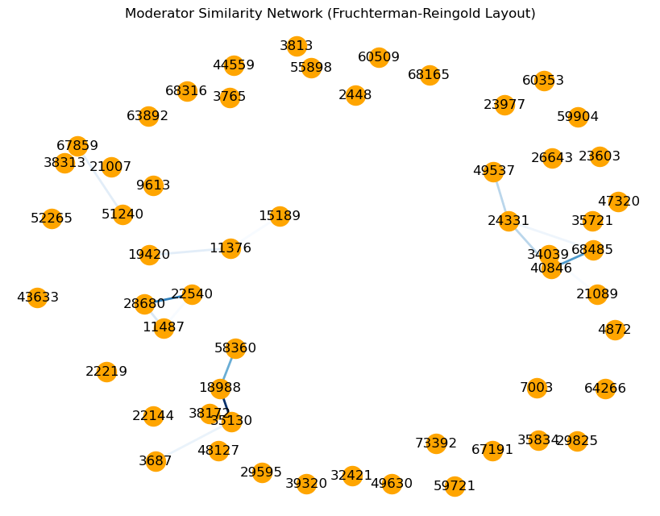

[figure not shown]

```
Cosine Similarity Matrix:
          24331     11487     40846     3687      49537     64266  9613   \
24331  1.000000  0.000000  0.288675  0.000000  0.288675  0.000000    0.0
11487  0.000000  1.000000  0.000000  0.079057  0.000000  0.000000    0.0
40846  0.288675  0.000000  1.000000  0.000000  0.000000  0.000000    0.0
3687   0.000000  0.079057  0.000000  1.000000  0.000000  0.000000    0.0
49537  0.288675  0.000000  0.000000  0.000000  1.000000  0.000000    0.0
64266  0.000000  0.000000  0.000000  0.000000  0.000000  1.000000    0.0
9613   0.000000  0.000000  0.000000  0.000000  0.000000  0.000000    1.0
55898  0.000000  0.000000  0.000000  0.000000  0.000000  0.000000    0.0
68316  0.000000  0.000000  0.000000  0.000000  0.000000  0.000000    0.0
19420  0.000000  0.000000  0.000000  0.007743  0.000000  0.093863    0.0

          55898  68316     19420  ...     44559  23977     68485     67191  \
24331  0.000000    0.0  0.000000  ...  0.000000    0.0  0.218218  0.064550
```

[output cut: 23 more lines]

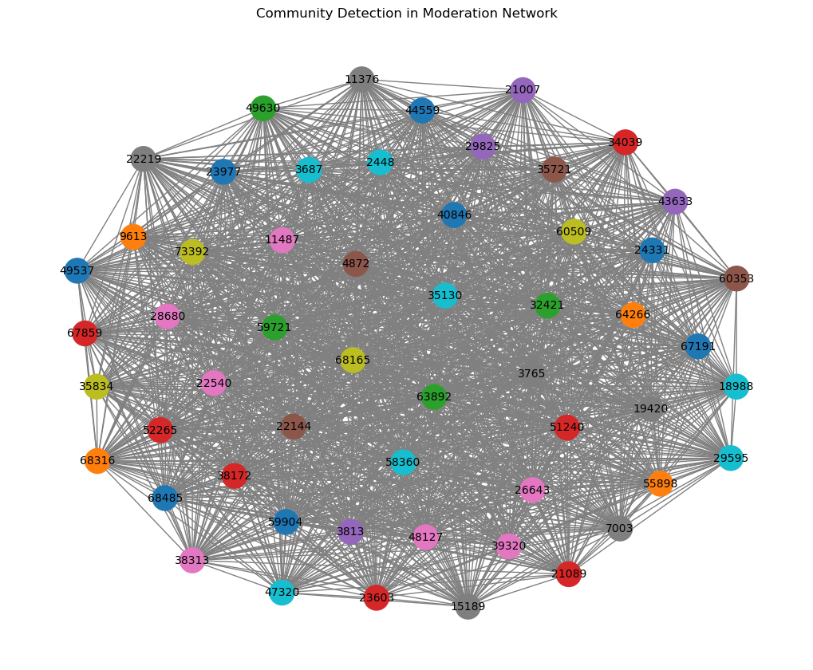

```
Community Summary:
Community 2: 4 instances
Community 42: 3 instances
Community 20: 4 instances
Community 5: 1 instances
Community 6: 1 instances
Community 7: 1 instances
Community 8: 1 instances
Community 9: 3 instances
Community 11: 1 instances
Community 12: 1 instances
Community 13: 1 instances
Community 14: 1 instances
Community 1: 2 instances
Community 16: 2 instances
Community 17: 1 instances
Community 18: 1 instances
Community 19: 1 instances
Community 21: 1 instances
Community 22: 1 instances
Community 23: 1 instances
Community 24: 1 instances
Community 25: 1 instances
Community 26: 1 instances
Community 28: 1 instances
Community 30: 1 instances
Community 31: 1 instances
Community 33: 1 instances
Community 34: 1 instances
Community 35: 1 instances
Community 36: 1 instances
Community 37: 1 instances
Community 38: 1 instances
Community 39: 1 instances
Community 41: 1 instances
Community 0: 1 instances
Community 32: 1 instances
Community 3: 1 instances
Community 4: 1 instances
Community 40: 1 instances
Community 10: 1 instances
Community 15: 1 instances
Community 27: 1 instances
Community 29: 1 instances
```

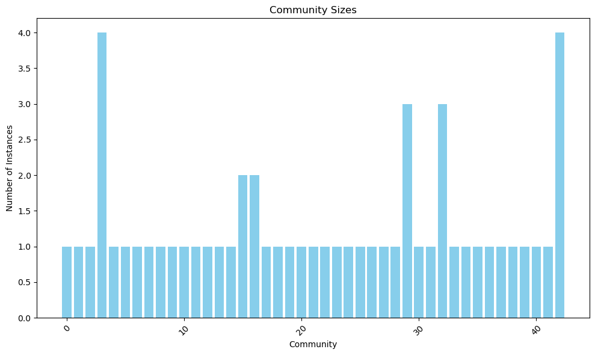

```python
# Example of community detection and visualization of community counts
moderation_data.visualize_community_counts(community_partition)
```

**Task 1: Findings on Moderation Activities in Mastodon**

1. **Misinformation and Spam Are Major Issues:** These are the most common moderation reasons, affecting a broad range of users. It suggests that Mastodon is facing the same issues as other platforms when it comes to controlling spam and false information.
2. **Harassment and Hate-Speech Are More Targeted:** These problems seem to pop up in particular communities or among certain groups, which means the platform’s moderation efforts are focusing more on these high-risk areas to keep users safe.
3. **Community-Based Moderation:** The data shows that moderation isn’t just about individual instances. Some groups on Mastodon appear to be working together to tackle common problems. This is a sign of the decentralized nature of the platform, where users help manage content collectively.

**Conclusion:** Mastodon’s moderation system shows that the platform is actively managing issues like misinformation and spam, but it also pays special attention to more sensitive content, such as harassment and hate-speech. The analysis highlights how the platform is balancing both widespread issues and targeted efforts to keep the environment safe and supportive for users.

**Task 2: Community Structure Analysis: Moderation Behavior Insights and Key Findings**

In this analysis, I used community detection methods to identify patterns in the moderation network. The Louvain method, which is based on optimizing modularity, was applied to detect communities of instances with similar moderation behaviors based on a cosine similarity matrix.

1. **Method Overview**

**Cosine Similarity Matrix:** The analysis began by calculating the cosine similarity between the instances using their moderation patterns. This matrix reflects the degree of similarity between pairs of instances, where a higher similarity indicates a stronger connection between the instances.

[output not shown]

2. **Community Distribution**

The communities detected were unevenly distributed, with some communities having significantly more instances than others. Larger communities typically represent widespread moderation behaviors or issues, while smaller communities tend to reflect more specific or unique issues.

3. **Notable Patterns**

Smaller communities may indicate more targeted moderation activities, possibly addressing niche problems or isolated incidents.

4. **Community Characteristics**

The larger communities likely represent the general trends in moderation, where common reasons (like spamming or offensive content) lead to widespread actions across instances.

The smaller communities may indicate that more specialized or unique moderation actions occur in specific instances, highlighting the complexity and diversity of moderation behavior.

This approach to community detection reveals important insights into the structure of moderation across instances and can help in identifying key areas for improvement or further study.

**Task 3: Reflection on the Project: Community Detection in Mastodon Moderation Network**

Working on the community detection project for Mastodon moderation was a fascinating and challenging journey. It gave me a chance to explore the complexities of social networks, particularly how communities form and behave in a decentralized online platform. Throughout this process, I encountered several challenges, implemented various solutions, and learned a lot along the way.

**Challenges Encountered:**

One of the primary challenges was dealing with the complexity of the network data. The dataset, represented as a cosine similarity matrix, initially made it hard to determine the connections between nodes. I had to figure out a way to interpret these similarities in a meaningful way and identify which connections should actually be considered significant.

1. **Solution:** To tackle this, I introduced a threshold for cosine similarity, filtering out connections with values below 0.2. This allowed me to focus on stronger, more relevant relationships, which ultimately improved both the accuracy and efficiency of the community detection process.

Another significant challenge came with visualizing the network. With numerous nodes and edges, the graph quickly became cluttered and difficult to interpret. Visualizing communities clearly is crucial to understanding the structure of the moderation network.

Finally, the interpretation of the Louvain method’s output posed a challenge. The Louvain method, which is great for detecting communities in a network, sometimes produced clusters that were difficult to relate to the specific context of moderation behavior on Mastodon. Understanding what each community represented in terms of moderation activity was crucial but not immediately obvious.

**Solutions Implemented:**

The solutions I implemented were primarily centered around refining the data preparation process, enhancing the visualization, and interpreting the Louvain method’s results. By filtering out weak connections in the similarity matrix and focusing on stronger ones, I was able to simplify the network and improve the accuracy of community detection. Modularizing the workflow into separate functions for detection, visualization, and summarization also helped maintain clarity and flexibility throughout the process.

**Lessons Learned:**

However, I recognize that the Louvain method, while effective, might not always provide the most meaningful communities when applied to more specific contexts, like moderation behaviors. In future work, I would consider exploring other methods or hybrid approaches to detect communities based on more specific criteria (e.g., types of moderation).

**Proposed Improvements:**

1. **Scalability:** For larger networks, I would explore more efficient algorithms or technologies. This might include using graph databases (e.g., Neo4j) or other community detection algorithms that can handle larger datasets more effectively.
2. **Refining Community Detection:** While the Louvain method is a good starting point, I believe that using more specialized algorithms could yield more meaningful communities, especially if we could detect communities based on specific moderation behaviors, like harassment versus misinformation.
3. **Improved Visualization:** In future iterations, I’d look into using interactive visualization tools such as Plotly or Dash. This would allow users to dynamically explore the network and communities, which would be especially helpful for larger, more complex datasets.
4. **Real-Time Analysis:** Integrating real-time data from Mastodon would provide an opportunity to analyze moderation behavior as it evolves. This could lead to more timely and actionable insights, particularly in understanding how communities form and change over time.

**Conclusion:**

Reflecting on the process, this project has been an insightful learning experience. It has deepened my understanding of network analysis, community detection, and the importance of effective visualization. By applying these methods, I was able to uncover meaningful insights into the moderation behaviors on Mastodon. Moving forward, I would focus on enhancing the scalability and accuracy of the techniques used, while also improving the interactivity of the visualizations. This project has shown me the power of data-driven insights in understanding complex social dynamics and how network analysis can be applied to real-world problems like moderation on social platforms.

**Task 4: Going Above and Beyond – Exploring Beyond the Scope**

In addition to completing the core tasks of community detection and analysis, I took the opportunity to delve deeper into the moderation to uncover additional insights that were not explicitly required.

4. **Geographical Patterns (Optional Exploration):**

Exploring whether there were any geographical patterns in the moderation behaviors, I could identify whether users from specific regions were subject to more or less moderation. This could uncover hidden biases or trends in how moderation is enforced based on geographical location.